## Loading and preprocessing the data

1.load the data

```r
library(dplyr)
```

```r
library(ggplot2)
setwd("C:/Users/liuzhi/Documents/R/work-directory")
act <- read.csv("activity.csv")
str(act)
```

‘data.frame’: 17568 obs. of 3 variables: $ steps : int NA NA NA NA NA NA NA NA NA NA … $ date : Factor w/ 61 levels “2012-10-01”,“2012-10-02”,..: 1 1 1 1 1 1 1 1 1 1 … $ interval: int 0 5 10 15 20 25 30 35 40 45 …

2.Process/transform the data (if necessary) into a format suitable for your analysis

```r
act$date <- as.Date(act$date)
str(act)
```

```
## 'data.frame':    17568 obs. of  3 variables:
##  $ steps   : int  NA NA NA NA NA NA NA NA NA NA ...
##  $ date    : Date, format: "2012-10-01" "2012-10-01" ...
##  $ interval: int  0 5 10 15 20 25 30 35 40 45 ...
```

## What is mean total number of steps taken per day?

3.Mean and median number of steps taken each day

```r
act1 <- group_by(act,date)
act2 <- mutate(act1,d_steps = sum(steps))
sub1 <- act2[,c(2,4)]
sub2 <- unique(sub1)
mean_missed <- mean(sub2$d_steps,na.rm = TRUE)
median_missed <- median(sub2$d_steps,na.rm = TRUE)
print(mean_missed)
```

```
## [1] 10754.92
```

```r
print(median_missed)
```

```
## [1] 10682.5
```

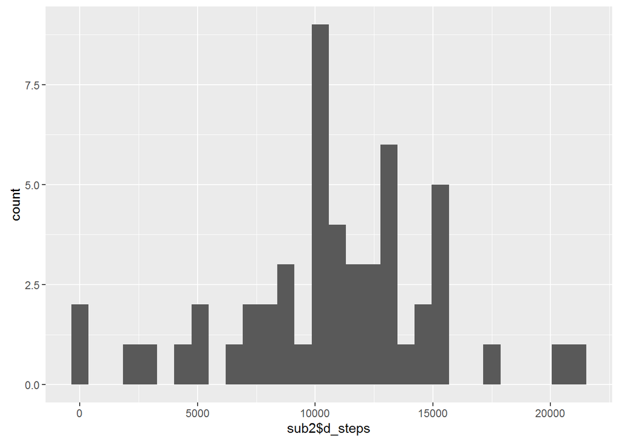

```r
qplot(sub2$d_steps)
```

## What is the average daily activity pattern?

5.The 5-minute interval that, on average, contains the maximum number of steps

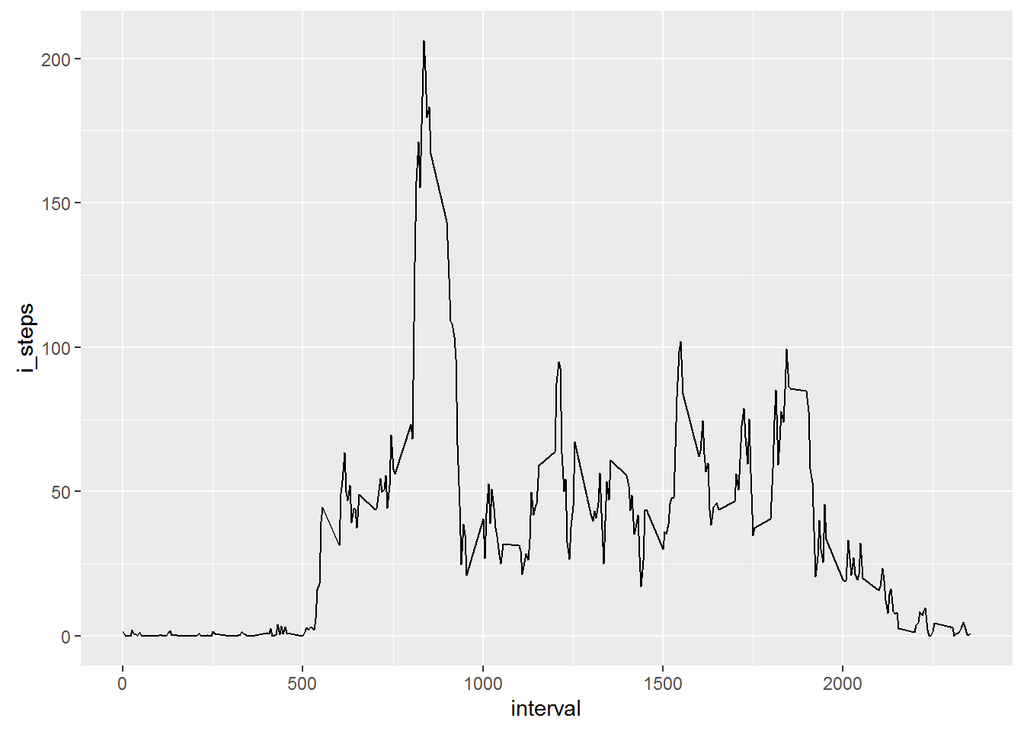

```r
act2_1 <- group_by(act,interval)
act2_2 <- mutate(act2_1,i_steps=mean(steps,na.rm = TRUE))
sub2_1 <- act2_2[,c(3,4)]
sub2_2 <- unique(sub2_1)
ggplot(data=sub2_2,aes(interval,i_steps))+geom_line()
```

```r
filter(sub2_2,i_steps == max(sub2_2$i_steps))
```

```
## Source: local data frame [1 x 2]
## Groups: interval [1]
##
##   interval  i_steps
##      (int)    (dbl)
## 1      835 206.1698
```

## Imputing missing values

```r
na_num <- sum(is.na(act[,1]))
print(na_num)
```

```
## [1] 2304
```

```
miss value exist in the 1st colume,then can count the amount of total number of missing values in the dataset.it's 2304.
```

6.filling in all of the missing values by mean for that 5-minute interval

```r
act3 = act
nrow <- length(act$steps)
nrow
```

```
## [1] 17568
```

```r
for(i in 1:nrow){
  if (is.na(act[i,1]))
    act3[i,1] <- act2_2[i,4]
}
```

7.Histogram of the total number of steps taken each day after missing values are imputed

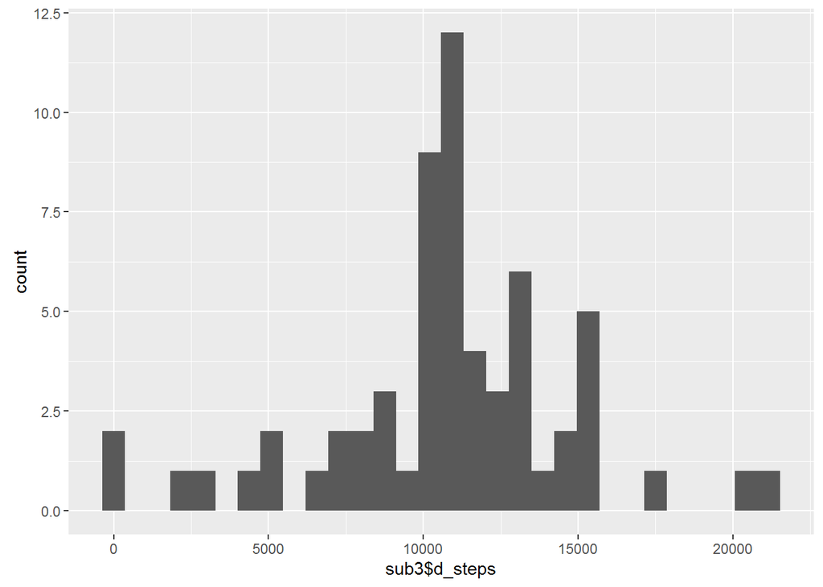

```r
act3_1 <- group_by(act3,date)
act3_2 <- mutate(act3_1,d_steps = sum(steps))
act3_3 <- act3_2[,c(2,4)]
sub3 <- unique(act3_3)
mean_filled <- mean(sub3$d_steps,na.rm = TRUE)
median_filled <- median(sub3$d_steps,na.rm = TRUE)

qplot(sub3$d_steps)
```

```r
mean_filled
```

```
## [1] 10766.19
```

```r
median_filled
```

```
## [1] 10766.19
```

```
mean value become from 1.0754923\times 10^{4} to 1.0766189\times 10^{4};
median value become from 1.06825\times 10^{4} to 1.0766189\times 10^{4}.
the mean and median both increased slightly after fill miss values.
```

## Are there differences in activity patterns between weekdays and weekends?

8.Panel plot comparing the average number of steps taken per 5-minute interval across weekdays and weekends

```r
act4 <- act
act4$weekday <- weekdays(act3$date)
print(unique(act4$weekday))
```

```
## [1] "星期一" "星期二" "星期三" "星期四" "星期五" "星期六" "星期日"
```

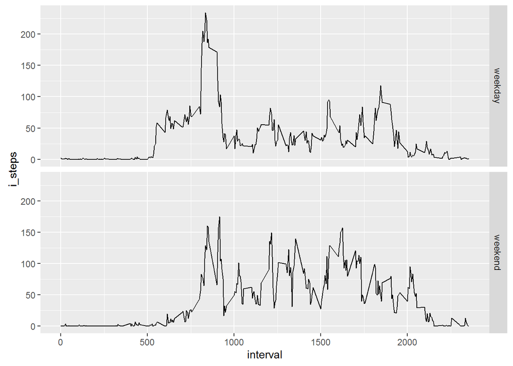

```r
for (j in 1:length(act[,1])) {
  if (act4[j,4]=="星期六" || act4[j,4]=="星期日")
    act4$day_end[j] = "weekend"
  else
    act4$day_end[j] = "weekday"
}

act4_1 <- group_by(act4,interval,day_end)
act4_2 <- mutate(act4_1,i_steps=mean(steps,na.rm = TRUE))
act4_3 <- act4_2[,c(3,5,6)]
act4_4 <- unique(act4_3)
ggplot(data=act4_4,aes(x=interval,y=i_steps)) +geom_line() + facet_grid(day_end~.)
```